# Introduction to Machine Learning (Syllabus/Code for Day 2): Solutions for Learning in Supervised and Unsupervised Settings

# 7 Overfitting

## 7.1 Bootstrapping Observations

- Bootstrap_aggregating
- Cross-validation_(statistics)
- [“Linear Model Selection by Cross-Validation,”](http://www.libpls.net/publication/MCCV_Shao_1993.pdf), Jun Shao, 1993
- [“Cross-validation failure: small sample sizes lead to large error bars,”](https://hal.inria.fr/hal-01545002/), Gaël Varoquaux, 2017
- (ESL) “7 Model Assessment and Selection”
- (ISLR) “Chapter 5 Resampling Methods”

## 7.2 Model Complexity/Parismony

- AIC (Akaike 1973)
- [Akaike information criterion (AIC)](https://en.wikipedia.org/wiki/Akaike_information_criterion)
- BIC (Schwarz 1978)
- [Bayesian information criterion (BIC)](https://en.wikipedia.org/wiki/Bayesian_information_criterion)

# 8 Curse of dimensionality

## 8.1 Feature Bagging/Subspace Mtethods

- [Random subspace method](https://en.wikipedia.org/wiki/Random_subspace_method)
- [“Bagging Predictors.”](https://link.springer.com/content/pdf/10.1007/BF00058655.pdf),Breiman, Leo. 1996. , Machine Learning 24:123–140.

# 9 Random Forests

- https://en.wikipedia.org/wiki/Random_forest
- [“RANDOM FORESTS”](https://www.stat.berkeley.edu/~breiman/randomforest2001.pdf) Leo Breiman, January 2001
- [“Exploratory Data Analysis using Random Forests”](http://zmjones.com/static/papers/rfss_manuscript.pdf)

```r
set.seed(123)
#install.packages('randomForest', dependencies=T)
p_load(randomForest)
forest <- randomForest(formula,
                       data = BreastCancer_train,
                       localImp = TRUE,
                       na.action=na.omit)
print(forest)
```

```
Call:
 randomForest(formula = formula, data = BreastCancer_train, localImp = TRUE,      na.action = na.omit)
               Type of random forest: classification
                     Number of trees: 500
No. of variables tried at each split: 3

        OOB estimate of  error rate: 2.62%
Confusion matrix:
    0   1 class.error
0 363  13  0.03457447
1   2 194  0.01020408
```

```r
set.seed(123)
p_load(randomForest)
forest_cv_model <- train(x=BreastCancer_train[,-c(10)],
                             y=as.factor(paste0('Outcome',BreastCancer_train$y)),
                             method = "rf",
                             trControl = cctrl1,
                             metric = "ROC"
                             #tuneGrid = expand.grid(alpha = 1,lambda = glmnet1_cv$lambda.1se)
                             )
print(forest_cv_model$results)
```

|  | mtry | ROC | Sens | Spec | ROCSD | SensSD | SpecSD |
| --- | --- | --- | --- | --- | --- | --- | --- |
| 1 | 2 | 0.9889304297 | 0.9706970128 | 0.9844736842 | 0.01146501538 | 0.01979802832 | 0.02501000108 |
| 2 | 5 | 0.9894617991 | 0.9652916074 | 0.9697368421 | 0.00951798141 | 0.02546323152 | 0.03513702676 |
| 3 | 9 | 0.9873701056 | 0.9599573257 | 0.9747368421 | 0.01124567675 | 0.02887124182 | 0.02664126214 |

```r
p_load(plotROC)
condition <- forest_cv_model$pred$mtry==5
out_of_sample_predictions5 <- data.frame(y_hat=forest_cv_model$pred$Outcome1[condition] ,
                                               y=BreastCancer_train$y[forest_cv_model$pred$rowIndex[condition]] ,
                                               model="Forest")
basicplot <- ggplot(bind_rows(out_of_sample_predictions,
                              out_of_sample_predictions2,
                              out_of_sample_predictions3,
                              out_of_sample_predictions4,
                              out_of_sample_predictions5),
                    aes(d = as.numeric(y), m = y_hat, color=model)) + geom_roc(n.cuts=0) +
                    style_roc(theme = theme_grey, xlab = "1 - Specificity") + ggtitle("AUC")
```

[output not shown]

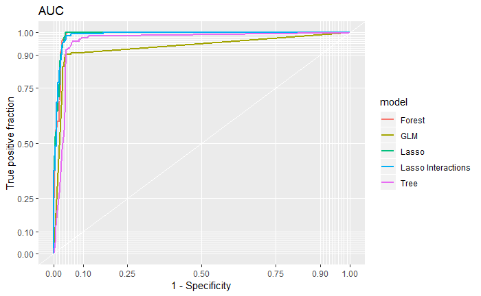

```r
basicplot
```

## 9.1 Depth

[Understanding random forests with randomForestExplainer](https://cran.rstudio.com/web/packages/randomForestExplainer/vignettes/randomForestExplainer.html), Aleksandra Paluszyńska

```r
set.seed(123)
#devtools::install_github("MI2DataLab/randomForestExplainer")
p_load(randomForestExplainer)
#install.packages('rlang')
min_depth_frame <- min_depth_distribution(forest)
save(min_depth_frame, file = "min_depth_frame.rda")
load("min_depth_frame.rda")
head(min_depth_frame, n = 10)
```

|  | tree | variable | minimal_depth |
| --- | --- | --- | --- |
| 1 | 1 | Bare.nuclei | 0 |
| 2 | 1 | Bl.cromatin | 1 |
| 3 | 1 | Cell.shape | 3 |
| 4 | 1 | Cell.size | 2 |
| 5 | 1 | Cl.thickness | 1 |
| 6 | 1 | Epith.c.size | 2 |
| 7 | 1 | Mitoses | 3 |
| 8 | 1 | Normal.nucleoli | 2 |
| 9 | 2 | Bl.cromatin | 0 |
| 10 | 2 | Cell.shape | 2 |

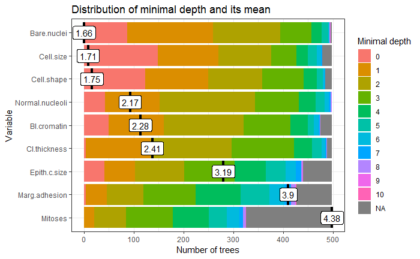

```r
# plot_min_depth_distribution(forest) # gives the same result as below but takes longer
plot_min_depth_distribution(min_depth_frame)
```

Variable Importance Pay particular attention to “accuracy_decrease” which is the drop in the classifier’s accuracy if that variable is shuffled destroying its information.

```r
importance_frame <- measure_importance(forest)
importance_frame
```

| variable | mean_min_depth | no_of_nodes | accuracy_decrease | gini_decrease | no_of_trees | times_a_root | p_value |
| --- | --- | --- | --- | --- | --- | --- | --- |
| Bare.nuclei | 1.664441767 | 1419 | 0.086412203114 | 44.049217552 | 495 | 87 | 0.00000000000000041139460491479703128578 |
| Bl.cromatin | 2.281469880 | 1153 | 0.018347261742 | 24.753681285 | 475 | 50 | 0.50184617917651097585007846646476536989 |
| Cell.shape | 1.750064257 | 1258 | 0.058966165106 | 56.556746796 | 485 | 123 | 0.00061091827564363628769866787493469928 |
| Cell.size | 1.709397590 | 1246 | 0.071658496985 | 66.823335434 | 478 | 149 | 0.00206709132011049113303302604549571697 |
| Cl.thickness | 2.410923695 | 1469 | 0.051605424233 | 13.878300001 | 488 | 4 | 0.00000000000000000000091863069678439283 |
| Epith.c.size | 3.188578313 | 912 | 0.010648229944 | 18.641776108 | 440 | 41 | 0.99999999999999655830862366201472468674 |
| Marg.adhesion | 3.898481928 | 919 | 0.009989292255 | 5.020749572 | 427 | 4 | 0.99999999999997868371792719699442386627 |
| Mitoses | 4.377124498 | 471 | 0.004664534440 | 2.216684293 | 326 | 0 | 1.00000000000000000000000000000000000000 |
| Normal.nucleoli | 2.168674699 | 1528 | 0.044008193446 | 25.134238897 | 498 | 42 | 0.00000000000000000000000000001591710611 |

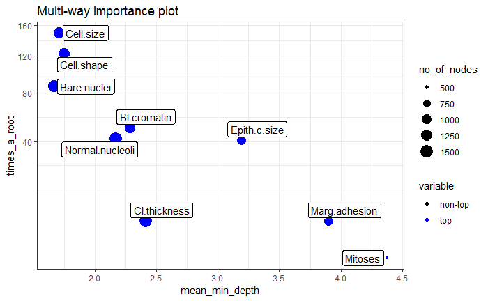

```r
plot_multi_way_importance(importance_frame, size_measure = "no_of_nodes")
```

```r
(vars <- important_variables(importance_frame, k = 5, measures = c("mean_min_depth", "no_of_trees")))
```

```
[1] "Bare.nuclei"     "Normal.nucleoli" "Cell.shape"      "Cell.size"       "Cl.thickness"
```

```r
interactions_frame <- min_depth_interactions(forest, vars)
head(interactions_frame[order(interactions_frame$occurrences, decreasing = TRUE), ])
```

|  | variable | root_variable | mean_min_depth | occurrences | interaction | uncond_mean_min_depth |
| --- | --- | --- | --- | --- | --- | --- |
| 43 | Normal.nucleoli | Cell.size | 1.169381107 | 307 | Cell.size:Normal.nucleoli | 2.168674699 |
| 42 | Normal.nucleoli | Cell.shape | 1.156808489 | 306 | Cell.shape:Normal.nucleoli | 2.168674699 |
| 23 | Cl.thickness | Cell.size | 1.321385251 | 304 | Cell.size:Cl.thickness | 2.410923695 |
| 3 | Bare.nuclei | Cell.size | 1.103866545 | 303 | Cell.size:Bare.nuclei | 1.664441767 |
| 22 | Cl.thickness | Cell.shape | 1.332187112 | 300 | Cell.shape:Cl.thickness | 2.410923695 |
| 2 | Bare.nuclei | Cell.shape | 1.363726116 | 288 | Cell.shape:Bare.nuclei | 1.664441767 |

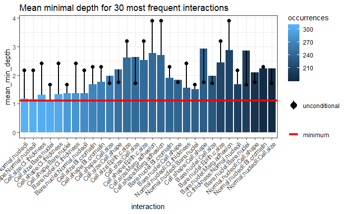

```r
plot_min_depth_interactions(interactions_frame)
```

```r
plot_predict_interaction(forest, BreastCancer_train[,-c(10)], "Cell.size", "Cl.thickness")
```

[output not shown]

Can even generate an automated report

```r
explain_forest(forest, interactions = TRUE, data = BreastCancer_train)
```

# 10 Compare out of Sample Accuracy

```r
set.seed(123)
df_predictions <- data.frame(y_true=BreastCancer_test$y,
                             y_hat_glm=stats::predict.glm(glm1, newdata=BreastCancer_onehot_test, type = "response" ),
                             y_hat_lasso = predict(glmnet1_cv, newx=BreastCancer_onehot_test %>%
                                                 select(-y) %>% data.matrix(), s=c("lambda.1se") ,
                                                 type = "response")[,1],
                              y_hat_lasso_twoway <- predict(glmnet_twoway_cv,
                                                            newx=BreastCancer_onehot_test_twoway %>%
                                                              data.matrix(),
                                      s=c("lambda.1se") , type = "response")[,1],
                             y_hat_single_tree = predict(single_decision_tree, newdata=BreastCancer_test,
                                                         type = "prob") %>% sapply(rbind) %>% t() %>%
                               data.frame() %>% pull(X2),
                             y_hat_forest = predict(forest, newdata=BreastCancer_test, type = "prob")[,'1']#,
                             #y_hat_nn = predict(NN, newdata=BreastCancer_test, type = "prob")
                             )
```

```
prediction from a rank-deficient fit may be misleading
```

```r
p_load(MLmetrics)
AUC(df_predictions$y_hat_glm,df_predictions$y_true) %>% round(3)
```

```
[1] 0.935
```

```r
AUC(df_predictions$y_hat_lasso,df_predictions$y_true) %>% round(3)
```

```
[1] 0.991
```

```r
AUC(df_predictions$y_hat_lasso_twoway,df_predictions$y_true) %>% round(3)
```

```
[1] 0.99
```

```r
AUC(df_predictions$y_hat_single_tree,df_predictions$y_true) %>% round(3)
```

```
[1] 0.972
```

```r
AUC(df_predictions$y_hat_forest,df_predictions$y_true) %>% round(3)
```

```
[1] 0.988
```

```r
table(df_predictions$y_hat_lasso>.5,
      df_predictions$y_true)
```

```
         0  1
  FALSE 79  4
  TRUE   3 41
```

# 11 Neural Networks

- [“Neural Networks, Manifolds, and Topology”](http://colah.github.io/posts/2014-03-NN-Manifolds-Topology/), Christopher Olah
- 550. Deep Learning, Ian Goodfellow and Yoshua Bengio and Aaron Courville, 2016, http://www.deeplearningbook.org/
- (PRML) “Chapter 5 Neural Networks”
- Tensorflow Playground
- [ConvNetJS Deep Learning in your browser](https://cs.stanford.edu/people/karpathy/convnetjs/)
- [KerasJS](https://transcranial.github.io/keras-js/#/)
- [“Understanding LSTM Networks,”](http://colah.github.io/posts/2015-08-Understanding-LSTMs/), Christopher Olah, August 27, 2015,
- [The Building Blocks of Interpretability](https://distill.pub/2018/building-blocks/), Chris Olah, Arvind Satyanarayan, Ian Johnson, Shan Carter, Ludwig Schubert, Katherine Ye, Alexander Mordvintsev, 2018, Distill
- [Feature Visualization How neural networks build up their understanding of images](https://distill.pub/2017/feature-visualization/), Chris Olah, Alexander Mordvintsev, Ludwig Schubert, Nov. 7, 2017, Distill

```r
p_load("neuralnet")
formula_onehot_2 = y + y_not ~ Cl.thickness + Cell.size + Cell.shape + Marg.adhesion + Epith.c.size +
    Bare.nuclei_1 + Bare.nuclei_10 + Bare.nuclei_2 + Bare.nuclei_4 +
    Bare.nuclei_3 + Bare.nuclei_9 + Bare.nuclei_7 + Bare.nuclei_5 +
    Bare.nuclei_8 + Bare.nuclei_6 + Bl.cromatin_3 + Bl.cromatin_9 +
    Bl.cromatin_1 + Bl.cromatin_2 + Bl.cromatin_4 + Bl.cromatin_5 +
    Bl.cromatin_7 + Bl.cromatin_8 + Bl.cromatin_6 + Bl.cromatin_10 +
    Normal.nucleoli_1 + Normal.nucleoli_2 + Normal.nucleoli_7 +
    Normal.nucleoli_4 + Normal.nucleoli_5 + Normal.nucleoli_3 +
    Normal.nucleoli_10 + Normal.nucleoli_6 + Normal.nucleoli_9 +
    Normal.nucleoli_8 + Mitoses_1 + Mitoses_5 + Mitoses_4 + Mitoses_2 +
    Mitoses_3 + Mitoses_7 + Mitoses_10 + Mitoses_8 + Mitoses_6
BreastCancer_onehot_train_2 = BreastCancer_onehot_train
BreastCancer_onehot_train_2$y_not = as.numeric(!as.logical(as.numeric(BreastCancer_onehot_train_2$y)-1))
BreastCancer_onehot_test_2 = BreastCancer_onehot_test
BreastCancer_onehot_test_2$y_not = as.numeric(!as.logical(as.numeric(BreastCancer_onehot_test_2$y)-1))
table(BreastCancer_onehot_test_2$y_not, BreastCancer_onehot_test_2$y)
```

```
     0  1
  0  0 45
  1 82  0
```

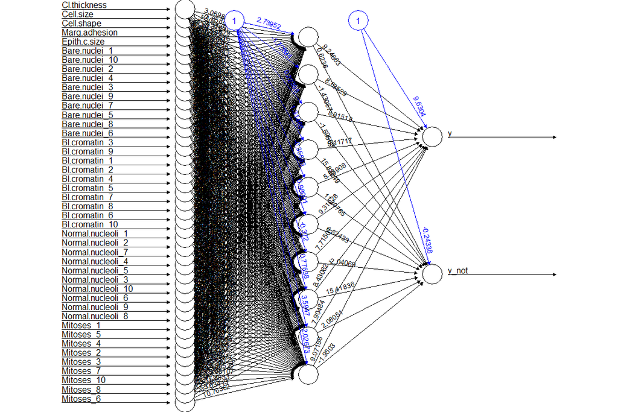

```r
NN = neuralnet(formula_onehot_2,
               data= BreastCancer_onehot_train_2 %>% data.matrix(),
               hidden = 10 ,
               linear.output = F
               )
# plot neural network
plot(NN)
```

# 12 Unsupervised Learning

- (ISLR) “Chapter 10 Unsupervised Learning”
- IMLR [“Chapter 4 Unsupervised Learning”](https://lgatto.github.io/IntroMachineLearningWithR/unsupervised-learning.html)

## 12.1 Dimensionality Reduction

Principal_component_analysis [Multiple correspondence analysis](https://en.wikipedia.org/wiki/Multiple_correspondence_analysis)

## 12.2 Clustering

- [Cluster analysis](https://en.wikipedia.org/wiki/Cluster_analysis%20%3Cbr/%3E)
- K-means_clustering
- [“Unsupervised Machine Learning: The hclust, pvclust, cluster, mclust, and more,”](https://quantdev.ssri.psu.edu/sites/qdev/files/Unsupervised_Machine_Learning_The_mclust_Package_and_others.html)

# 13 Special Topics

## 13.1 Time

- [“Investigating Sequences in Ordinal Data: A New Approach With Adapted Evolutionary Models,”](https://www.cambridge.org/core/journals/political-science-research-and-methods/article/investigating-sequences-in-ordinal-data-a-new-approach-with-adapted-evolutionary-models/F3747D8A1908902BA7F26C5EE28AFAEF),Patrik Lindenfors, Fredrik Jansson, Yi-ting Wang and Staffan I. Lindberg, Christian Lopez, 05 March 2018,

## 13.2 Text

- [“Text Mining with R: A Tidy Approach,”](https://www.tidytextmining.com/), Julia Silge and David Robinson, 2018-04-02,
- [“Introducing Monte Carlo Methods with R,”](https://www.slideshare.net/xianblog/introducing-monte-carlo-methods-with-r)
- [“Text as Data,”](http://web.stanford.edu/~gentzkow/research/text-as-data.pdf), Matthew Gentzkow, Bryan T. Kelly, Matt Taddy

## 13.3 Images

- https://keras.rstudio.com/articles/examples/cifar10_cnn.html

# 14 Examples

- [“Examining Explanations for Nuclear Proliferation”](https://doi.org/10.1093/isq/sqv007), Mark S. Bell, International Studies Quarterly, Volume 60, Issue 3, 1 September 2016, Pages 520–529

# 15 Extras

## 15.1 Gradient Boosting

- Terence Parr and Jeremy Howard, “How to explain gradient boosting,” http://explained.ai/gradient-boosting/index.html
- [XGBoost eXtreme Gradient Boosting](https://github.com/dmlc/xgboost)

## 15.2 SVM

- Support_vector_machine

## 15.3 Nearest Neighbor

- K-nearest_neighbors_algorithm

## 15.4 How the Sausage is Made

- [“Troubling Trends in Machine Learning Scholarship”](https://www.dropbox.com/s/ao7c090p8bg1hk3/Lipton%20and%20Steinhardt%20-%20Troubling%20Trends%20in%20Machine%20Learning%20Scholarship.pdf?dl=0), Zachary C. Lipton∗& Jacob Steinhardt, July 9, 2018